# Datos cuallitativos 8 - examen

Moises

1/3/2020

Instalad y cargad el paquete MASS. Encontraréis una tabla de datos llamada birthwt sobre factores que pueden incidir en el peso de los niños al nacer. Con str() y head(), explorad la estructura, y con help(), mirad el significado de cada variable.

```r
library(MASS)
```

1. Utiliza str() y head() para explorar la estructura, y con help(), mirar el significado de cada variable.

```r
df_bebes = birthwt

str(df_bebes)
```

```
## 'data.frame':    189 obs. of  10 variables:
##  $ low  : int  0 0 0 0 0 0 0 0 0 0 ...
##  $ age  : int  19 33 20 21 18 21 22 17 29 26 ...
##  $ lwt  : int  182 155 105 108 107 124 118 103 123 113 ...
##  $ race : int  2 3 1 1 1 3 1 3 1 1 ...
##  $ smoke: int  0 0 1 1 1 0 0 0 1 1 ...
##  $ ptl  : int  0 0 0 0 0 0 0 0 0 0 ...
##  $ ht   : int  0 0 0 0 0 0 0 0 0 0 ...
##  $ ui   : int  1 0 0 1 1 0 0 0 0 0 ...
##  $ ftv  : int  0 3 1 2 0 0 1 1 1 0 ...
##  $ bwt  : int  2523 2551 2557 2594 2600 2622 2637 2637 2663 2665 ...
```

```r
head(df_bebes)
```

```
##    low age lwt race smoke ptl ht ui ftv  bwt
## 85   0  19 182    2     0   0  0  1   0 2523
## 86   0  33 155    3     0   0  0  0   3 2551
## 87   0  20 105    1     1   0  0  0   1 2557
## 88   0  21 108    1     1   0  0  1   2 2594
## 89   0  18 107    1     1   0  0  1   0 2600
## 91   0  21 124    3     0   0  0  0   0 2622
```

2. Calcula una tabla de frecuencias relativas marginales de los pares (raza de la madre, peso inferior a 2.5 kg o no) que permita ver si la raza de la madre influye en el peso del bebé.

```r
df_bebes$bwt[df_bebes$bwt < 2500] = 0
df_bebes$bwt[df_bebes$bwt >= 2500] = 1

madre_raza = as.factor(df_bebes$race)
madre_raza = factor(madre_raza, levels = c(1,2,3), labels = c("Blanca","Negra","Otro"))

peso_bebe = as.factor(df_bebes$bwt)
peso_bebe = factor(peso_bebe, levels = c(1,0), labels = c("Mayor o igual a 2.5 KG","Menor a 2.5 KG"))

prop.table(table(madre_raza,peso_bebe),margin = 1)
```

```
##           peso_bebe
## madre_raza Mayor o igual a 2.5 KG Menor a 2.5 KG
##     Blanca              0.7604167      0.2395833
##     Negra               0.5769231      0.4230769
##     Otro                0.6268657      0.3731343
```

```r
#Aqui se puede ver que normalmente los bebes de madres blancas suelen nacer con un peso mayor a 2.5KG a difernecia de otras razas
```

3. Dibuja un diagrama de mosaico de la tabla del ejercicio anterior.

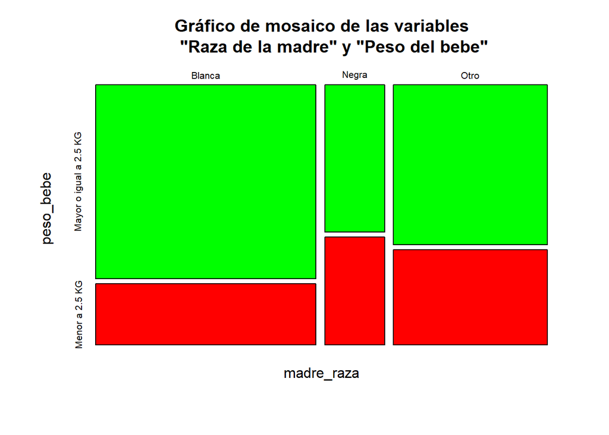

```r
plot(table(madre_raza,peso_bebe), main="Gráfico de mosaico de las variables
     \"Raza de la madre\" y \"Peso del bebe\"",col=c("green","red"))
```

4. Dibuja un diagrama bidimensional de barras, con las barras organizadas en bloques, que permita visualizar la información de los ejercicios anteriores. Aprovecha para nombres adecuados a los bloques, colores a las barras, y añadir una leyenda que explique qué representa cada barra.

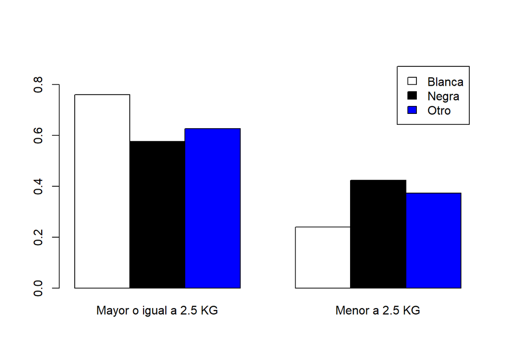

```r
barplot(prop.table(table(madre_raza,peso_bebe),margin = 1),beside=TRUE,legend.text = TRUE,col=c("white","black","blue"), ,ylim=c(0,0.90))
```

5. ¿Se puede obtener alguna conclusión de la tabla y el diagrama de barras anterior? Argumenta tu respuesta

```r
relacion_raza_peso = prop.table(table(madre_raza,peso_bebe),margin = 1)

diferencia_blanca_negra = round((relacion_raza_peso["Blanca","Mayor o igual a 2.5 KG"] - relacion_raza_peso["Negra","Mayor o igual a 2.5 KG"])*100,2)

diferencia_blanca_otro = round((relacion_raza_peso["Blanca","Mayor o igual a 2.5 KG"] - relacion_raza_peso["Otro","Mayor o igual a 2.5 KG"])*100,2)
```

Ahi se puede ver que normalmente los bebes de madres blancas suelen nacer con un peso mayor a 2.5KG. De hecho en comparacion con las madres negras suele ser un 18.35% mas y en relacion a las otras razas suele ser un 13.36% mas

6. Repite los cuatro ejercicios anteriores para los pares (madre fumadora o no, peso inferior a 2.5 kg o no) y para los pares (madre hipertensa o no, peso inferior a 2.5 kg o no.

```r
df_bebes = birthwt

df_bebes$bwt[df_bebes$bwt < 2500] = 0
df_bebes$bwt[df_bebes$bwt >= 2500] = 1

madre_fumadora = as.factor(df_bebes$smoke)
madre_fumadora = factor(madre_fumadora, levels = c(1,0), labels = c("SI fuma","NO fuma"))

madre_hipertensa = as.factor(df_bebes$ht)
madre_hipertensa = factor(madre_hipertensa, levels = c(1,0), labels = c("Es hipertensa","NO es hipertensa"))

peso_bebe = as.factor(df_bebes$bwt)
peso_bebe = factor(peso_bebe, levels = c(1,0), labels = c("Mayor o igual a 2.5 KG","Menor a 2.5 KG"))

##Ejercicio 6.1
prop.table(table(madre_fumadora,peso_bebe),margin = 1) #Relacion madre fumadora con peso del bebe
```

```
##               peso_bebe
## madre_fumadora Mayor o igual a 2.5 KG Menor a 2.5 KG
##        SI fuma              0.5945946      0.4054054
##        NO fuma              0.7478261      0.2521739
```

```r
prop.table(table(madre_hipertensa,peso_bebe),margin = 1) #Relacion madre hipertensa con peso del bebe
```

```
##                   peso_bebe
## madre_hipertensa   Mayor o igual a 2.5 KG Menor a 2.5 KG
##   Es hipertensa                 0.4166667      0.5833333
##   NO es hipertensa              0.7062147      0.2937853
```

```r
#Aqui se puede ver que normalmente los bebes de madres blancas suelen nacer con un peso mayor a 2.5KG a difernecia de otras razas
```

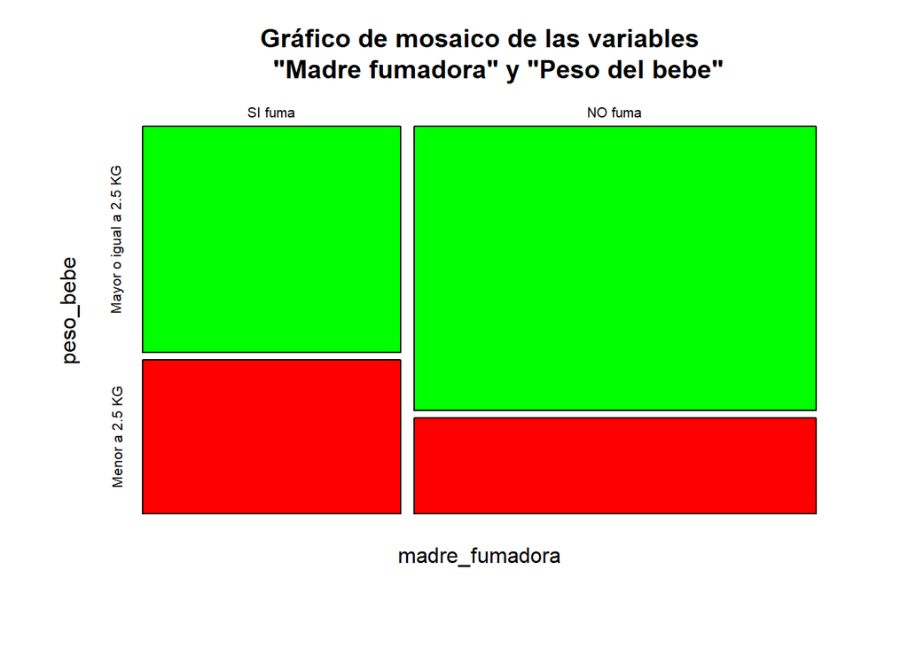

```r
##Ejercicio 6.2

plot(table(madre_fumadora,peso_bebe), main="Gráfico de mosaico de las variables
     \"Madre fumadora\" y \"Peso del bebe\"",col=c("green","red"))
```

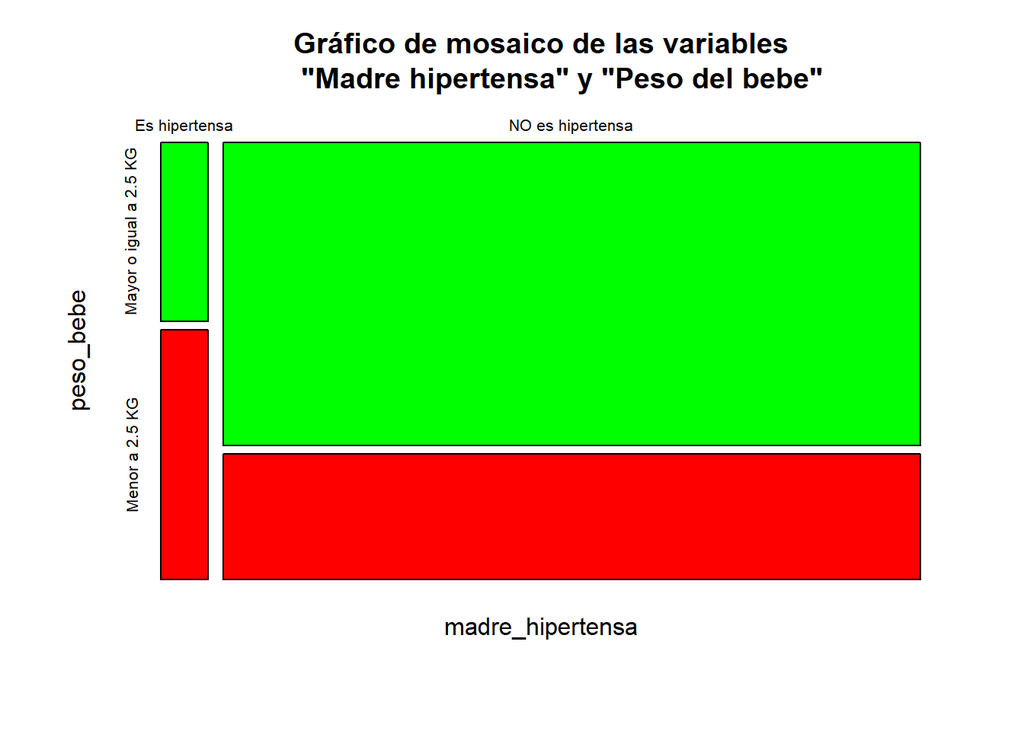

```r
plot(table(madre_hipertensa,peso_bebe), main="Gráfico de mosaico de las variables
     \"Madre hipertensa\" y \"Peso del bebe\"",col=c("green","red"))
```

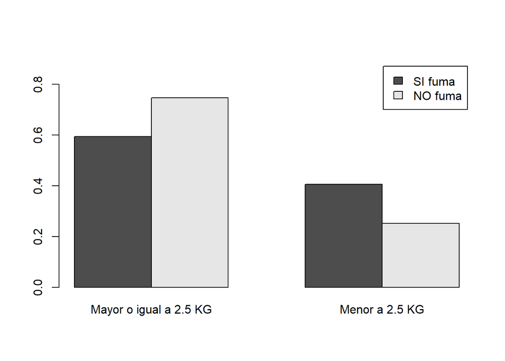

```r
##Ejercicio 6.3

barplot(prop.table(table(madre_fumadora,peso_bebe),margin = 1),beside=TRUE,legend.text = TRUE, ylim=c(0,0.90))
```

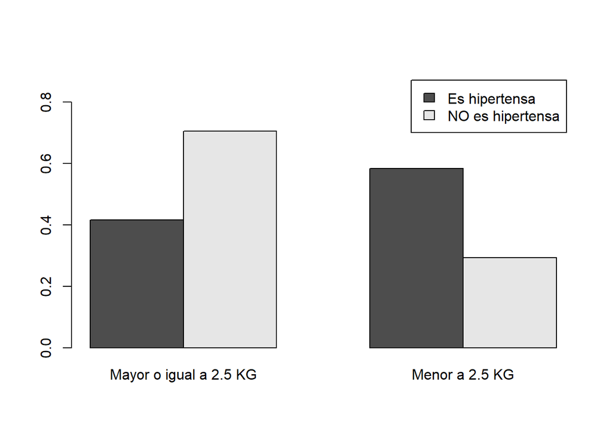

```r
barplot(prop.table(table(madre_hipertensa,peso_bebe),margin = 1),beside=TRUE,legend.text = TRUE, ylim=c(0,0.90))
```

```r
##Ejercicio 6.4

relacion_raza_fuma = prop.table(table(madre_fumadora,peso_bebe),margin = 1)

diferencia_blanca_negra_fuma = round((relacion_raza_fuma["NO fuma","Mayor o igual a 2.5 KG"] - relacion_raza_fuma["SI fuma","Mayor o igual a 2.5 KG"])*100,2)


relacion_raza_hipertensa = prop.table(table(madre_hipertensa,peso_bebe),margin = 1)

diferencia_blanca_negra_hiper = round((relacion_raza_hipertensa["NO es hipertensa","Mayor o igual a 2.5 KG"] - relacion_raza_hipertensa["Es hipertensa","Mayor o igual a 2.5 KG"])*100,2)
```

Ahi se puede ver que normalmente los bebes de madres NO fumadoras en comparacion con las madres fumadoras, en un 15.32% mas de las ocasiones suelen nacer con bebes mayores a 2.5 KG

y tambien se puede ver que normalmente los bebes de madres NO hipertensas en comparacion con las madres hipertensas, en un 28.95% mas de las ocasiones suelen nacer con bebes mayores a 2.5 KG

7. Calcula una tabla de frecuencias relativas marginales de las ternas (raza de la madre, madre fumadora o no, peso inferior a 2.5 kg o no) que permita ver si la raza de la madre y su condición de fumadora o no fumadora influyen en el peso del bebé.

```r
ftable(prop.table(table(madre_fumadora,madre_raza,peso_bebe),margin = 3))
```

```
##                           peso_bebe Mayor o igual a 2.5 KG Menor a 2.5 KG
## madre_fumadora madre_raza
## SI fuma        Blanca                           0.25384615     0.32203390
##                Negra                            0.03076923     0.10169492
##                Otro                             0.05384615     0.08474576
## NO fuma        Blanca                           0.30769231     0.06779661
##                Negra                            0.08461538     0.08474576
##                Otro                             0.26923077     0.33898305
```

8.Dibuja un diagrama de mosaico de la tabla del ejercicio anterior.

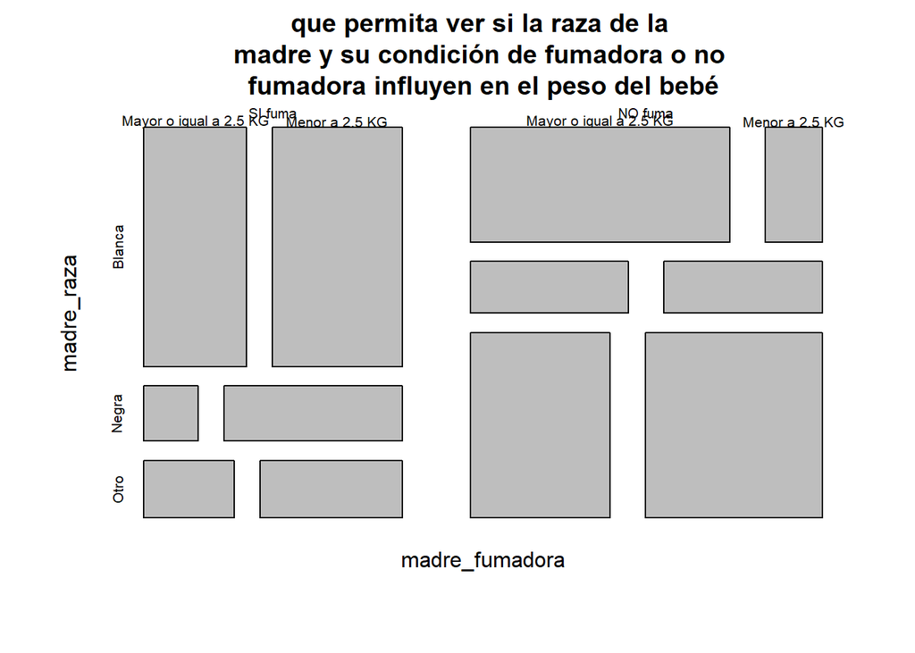

```r
plot(prop.table(table(madre_fumadora,madre_raza,peso_bebe),margin = 3), main="que permita ver si la raza de la \nmadre y su condición de fumadora o no \nfumadora influyen en el peso del bebé")
```